# Dashboard: Predicting Postpartum Relationship Satisfaction Collapse

[output not shown]

# 1 Method

The Workflow for Open Reproducible Code in Science (WORCS) was used to create a reproducible research archive (**vanlissaWORCSWorkflowOpen2020?**). All analysis code, supplemental materials and synthetic data are available at https://github.com/cjvanlissa/brabant_studie. The original data and all study documentation are available under controlled access.

## 1.1 Participants and procedure

Participants were 2865 expecting mothers enrolled in the Brabant Study.

## 1.2 Measures

| Name | Parameters | chisq | df | cfi | tli | srmr |
| --- | --- | --- | --- | --- | --- | --- |
| Configural | 680 | 169296.535846819 | 5604 | 0.97883357192415 | 0.978176370195885 | 0.0972569068656592 |
| Metric | 592 | 186840.068944543 | 5692 | 0.976576466650979 | 0.9762225622469 | 0.101514772550823 |
| Strict | 601 | 186840.068988088 | 5683 | 0.976575302891291 | 0.976183723404167 | 0.101514813737253 |

Table 1.1: CFAs for dependent variable DAS

### 1.2.1 Predictors

We included 59 predictors. Table 1.2 shows descriptive statistics for categorical variables, 1.3 for continuous variables, and 1.4 for multi-item scales.

| name | n | unique | mode | mode_prop | v | Interpretation |
| --- | --- | --- | --- | --- | --- | --- |
| Sexdetermination_12 | 2764 | 4 | Yes | 0.8082489146164978 | 0.3272496706675239 | Knowledge of gender baby at ultrasound (yes/no) |
| Sexpreference_12 | 2764 | 3 | No preference | 0.807163531114327 | 0.3268687654587303 | Preference of boy or girl |
| Pregnancyloss_12 | 2764 | 2 | No | 0.723589001447178 | 0.4000159168637076 | (Spontaneous) abortion before current pregnancy (yes/no) |
| Prevdelivery_12 | 2759 | 2 | No | 0.5222906850308082 | 0.4990062507217147 | Ever given birth before |
| Samepartner_12 | 1317 | 2 |  | 1.175398633257403 | 0.06882718771926499 | Pregnancy from same partner as previous pregnancy |
| Recentmiscarriage_12 | 1317 | 2 |  | 1.175398633257403 | 0.3131942606727398 | Miscarriage between previous and current pregnancy |
| Problemsprevpreg_12 | 2865 | 2 | 0 | 0.8157068062827225 | 0.3006584249335271 | Problems during a previous pregnancy |
| Problemsprevdeliv_12 | 2762 | 3 | N/A | 0.5126719768283853 | 0.6143920203905175 | Problems during a previous delivery |
| Plannedpreg_12 | 2762 | 2 | Yes | 0.9170890658942795 | 0.1520734222228748 | Planned pregnancy (Yes/No) |
| Locationdelivery_12 | 2762 | 3 | Hospital | 0.7845763939174512 | 0.3610788496618795 | Location planned to give birth |

[output cut: 22 more lines]

Table 1.2: Categorical predictor descriptive statistics. Unique: unique values, including missing. Mode: most common value. Mode_prop: proportion of cases with the mode value. V: categorical variable dispersion (similar to standard deviation for continuous variables).

| name | n | mean | sd | min | max | skew | kurt | Interpretation |
| --- | --- | --- | --- | --- | --- | --- | --- | --- |
| Age_12 | 2768 | -2.88432276113204e-16 | 1 | -3.62759616019464 | 3.728983402617251 | 0.1636235325822146 | 0.03695599112157488 | Age of participant |
| Height_12 | 2761 | -1.888771660346634e-15 | 1 | -4.578607996020755 | 3.485537253145208 | 0.01185094204411841 | 0.1541136478773582 | Length in cm |
| Weightprepreg_12 | 2751 | 2.175469000021132e-16 | 1 | -2.15722770521202 | 5.640562072396909 | 1.335418255172238 | 2.759797240725132 | Weight in kg before pregnancy |
| Weightpreg_20 | 2303 | -2.15593284223464e-16 | 1 | -2.488126941320955 | 5.197565897760537 | 1.134983886922984 | 1.965629888986187 | Weight in kg |
| Absence_12 | 900 | 1.952262618540621e-17 | 1 | -0.4071531946546898 | 14.06854701824019 | 6.942099961399183 | 67.14825772638358 | Info w.r.t. absenteeism |
| Maternityleave_12 | 2520 | -2.465501554569477e-17 | 1 | -2.9693210770242 | 29.5010567264589 | 8.747139752856208 | 301.2701562715189 | Maternity leave from which week |
| SMUfreq_12 | 2233 | 1.025396980297518e-16 | 1 | -1.738845560876796 | 1.359213865793655 | -0.1055253561356555 | -1.08708127925831 | Frequency social media usage (per day/week) |

Table 1.3: Numeric predictor descriptive statistics.

| name | n | items | mean | sd | min | max | skew | kurt | cfi | tli | comp_rel | Interpretation |
| --- | --- | --- | --- | --- | --- | --- | --- | --- | --- | --- | --- | --- |
| BFI_2S_28 | 2335 | 30 | -5.813740927824213e-16 | 0.9999999999999999 | -3.630048740052699 | 3.542503667836489 | 0.002401297905139009 | 0.1496487687980701 | 0.6990199919829498 | 0.6767251765742794 | 0.2685469967434857 |  |
| BSMAS_12 | 2233 | 6 | 1.372841747358094e-16 | 0.9999999999999999 | -1.078458391997501 | 4.707279275471012 | 1.027124632184663 | 0.8521525856437671 | 0.9879489869915609 | 0.9799149783192681 | 0.8287608094935589 | Bergen Social Media Addiction Scale |
| Complaints_12 | 2563 | 23 | 1.564191968606641e-16 | 1 | -1.783885196454152 | 4.143088474317616 | 0.7613730766684624 | 0.3565495406390049 | 0.8859194314921669 | 0.8745113746413836 | 1.019139895098318 | Physical and cognitive complaints |
| COVID19_PPQ_12 | 720 | 15 | 4.247783644890152e-16 | 0.9999999999999999 | -3.4444917219646 | 3.345282509503894 | -0.1203298689874735 | 0.6857163604393985 | 0.8243041284124693 | 0.7950214831478808 | 0.476102316452293 |  |
| DAS_12 | 2674 | 9 | 5.100723011717776 | 0.4309408180568341 | 1.222222222222222 | 5.888888888888889 | -1.534811883596088 | 5.96853069309241 | 0.9731489461981447 | 0.9641985949308596 | 0.816659130081959 | Dyadic Adjustment Scale |
| DAS_1y6mPP | 1072 | 9 | 4.741189883913765 | 0.5146771783447261 | 1.555555555555556 | 5.666666666666667 | -1.473564543567015 | 4.193456321540256 | 0.9854557886543353 | 0.9806077182057803 | 0.8791034880878473 | Dyadic Adjustment Scale |
| DAS_1yPP | 1136 | 9 | 4.96919014084507 | 0.506869694761076 | 2.555555555555555 | 5.888888888888889 | -1.425881786676439 | 3.140514140580855 | 0.9841657665634177 | 0.9788876887512236 | 0.869130250522289 | Dyadic Adjustment Scale |
| DAS_20 | 2433 | 9 | 5.122939215417637 | 0.4386004949525985 | 1.555555555555556 | 5.888888888888889 | -1.212202219800661 | 3.202160706170367 | 0.9699267856223558 | 0.9599023808298077 | 0.8471472730314277 | Dyadic Adjustment Scale |
| DAS_28 | 2297 | 9 | 5.137135393992164 | 0.4517879005509038 | 1.555555555555556 | 5.888888888888889 | -1.445201977698792 | 4.721119186748501 | 0.9762460300767155 | 0.9683280401022873 | 0.8429625743590493 | Dyadic Adjustment Scale |
| DAS_2y6mPP | 905 | 9 | 4.577409453652548 | 0.513913670444071 | 1.777777777777778 | 5.555555555555555 | -1.517475092802313 | 4.207670090302041 | 0.9790557545586894 | 0.9720743394115859 | 0.8761786701991708 | Dyadic Adjustment Scale |

[output cut: 22 more lines]

Table 1.4: Scale predictor descriptive statistics.

## 1.3 Results

### 1.3.1 Variable Importance

Variable importance for a specific predictor is defined as the decrease in model fit that occurs when randomly shuffling the values of that predictor, thus breaking its association with the focal parameter. If a predictor was important, then the model fit should become worse when it is shuffled. To obtain an unbiased estimate, variable importance is computed based on observations not included in each tree’s bootstrap sample, and then averaged across trees.

The Figure below show the permutation importance for all predictors whose importance exceeded 0.

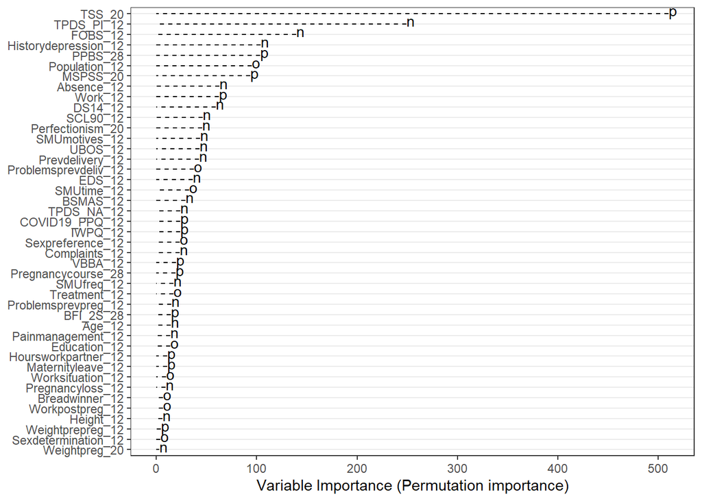

## 1.4 Marginal Association

Shape of association is determined as follows: First, take a sequence of potential values for that predictor at which to determine the predicted value for the focal parameter. We used 20 evenly spaced values for continuous predictors, and all categories of nominal predictors. We used Monte Carlo integration to average over the effect of all other predictors. Specifically, we calculated the focal parameter value at a specific value of the predictor, for all cases in the dataset. By taking the median predicted value for the focal parameter across all cases, we average out the effect of other predictors. Variable importance plots show the change in the focal parameter along this grid of predictor values.

Additionally, we classified the shapes of association into (monotonously) increasing, decreasing, convave, convex, step function(up and down), logistic (S-shaped), and “other”. We used BIC to select the shape that best balanced fit and complexity.

## 1.5 All Partial Dependence Plots

### plot_TSS_20

[figure not shown]

### plot_TPDS_PI_12

[figure not shown]

### plot_FOBS_12

[figure not shown]

### plot_Historydepression_12

[figure not shown]

### plot_PPBS_28

[figure not shown]

### plot_Population_12

[figure not shown]

### plot_MSPSS_20

[figure not shown]

### plot_Absence_12

[figure not shown]

### plot_Work_12

[figure not shown]

### plot_DS14_12

[figure not shown]

### plot_SCL90_12

[figure not shown]

### plot_Perfectionism_20

[figure not shown]

### plot_SMUmotives_12

[figure not shown]

### plot_UBOS_12

[figure not shown]

### plot_Prevdelivery_12

[figure not shown]

### plot_Problemsprevdeliv_12

[figure not shown]

### plot_EDS_12

[figure not shown]

### plot_SMUtime_12

[figure not shown]

### plot_BSMAS_12

[figure not shown]

### plot_TPDS_NA_12

[figure not shown]

### plot_COVID19_PPQ_12

[figure not shown]

### plot_IWPQ_12

[figure not shown]

### plot_Sexpreference_12

[figure not shown]

### plot_Complaints_12

[figure not shown]

### plot_VBBA_12

[figure not shown]

### plot_Pregnancycourse_28

[figure not shown]

### plot_SMUfreq_12

[figure not shown]

### plot_Treatment_12

[figure not shown]

### plot_Problemsprevpreg_12

[figure not shown]

### plot_BFI_2S_28

[figure not shown]

### plot_Age_12

[figure not shown]

### plot_Painmanagement_12

[figure not shown]

### plot_Education_12

[figure not shown]

### plot_Hoursworkpartner_12

[figure not shown]

### plot_Maternityleave_12

[figure not shown]

### plot_Worksituation_12

[figure not shown]

### plot_Pregnancyloss_12

[figure not shown]

### plot_Breadwinner_12

[figure not shown]

### plot_Workpostpreg_12

[figure not shown]

### plot_Height_12

[figure not shown]

### plot_Weightprepreg_12

[figure not shown]

### plot_Sexdetermination_12

[figure not shown]

### plot_Weightpreg_20

[figure not shown]